# Introduction

Social media have through recent years grown and have become an important part of our lives. This notebook wants to explore whether it is possible to use data from reddit to detect misogyny in social media platforms and create a machine learning model to detect misogyny on these platforms. The reason we have chosen reddit to detect misogynistic content is according to (Farrell et al., 2019) which results indicate that misogynistic content on reddit have been growing and the content have increased in a more violent manner. The dataset is from the article "An Expert Annotated Dataset for the Detection of Online Misogyny" (Ella Guest et. al., 19-Apr-2021) containing 6567 entries from reddit based on posts and comments. This article has been used as the main source of validity on defining misogyny, of which the article states that the dataset they present has the purpose of: "(The dataset) can be used to develop more accurate and nuanced classification models.".

The definition of misogynistic in the article derives from "2k Urban Dictionary definitions of which half are labelled as misogynistic." which they have summerised as the following definition: "Misogynistic content directs abuse at women or a closely related gendered group (e.g. feminists)"

The notebook will examine the problem by:

- Focusing on how to solve a categorical problem and build a machine learning model which can predict whether a comment is misogynistic or not.

Link to functioning notebook: https://colab.research.google.com/drive/1E7e6sYaBHpH9p0RqtVvkSpVTx8qgPfFu?usp=sharing

## Order of operations

- Package loading
- Preprocessing / EDA
- Unsupervised machine learning
  - Topic modeling
  - Clustering
- Supervised machine learning
  - Logistic regression
  - XGB model
  - Hyperparameter tuning of XGB
- Applying SML model to new data
  - Preprocessing twitter data
  - Untuned XGB model
  - Tuned XGB model
- Conclusion
  - Caveats

# Package loading

```python
import pandas as pd
import numpy as np
import spacy
nlp = spacy.load('en')
from sklearn.feature_extraction.text import TfidfVectorizer
import itertools
from collections import Counter
import matplotlib.pyplot as plt
from nltk.probability import FreqDist as FD
from wordcloud import WordCloud
from gensim.corpora.dictionary import Dictionary
from gensim.models.tfidfmodel import TfidfModel
from gensim.models.lsimodel import LsiModel
from gensim.similarities import MatrixSimilarity
!pip install "umap.learn==0.3.10" -qq
import umap.umap_ as umap
from sklearn.cluster import KMeans
import seaborn as sns
sns.set(rc = {'figure.figsize':(15,8)})
from sklearn.model_selection import train_test_split
from sklearn.linear_model import LogisticRegression
from sklearn.preprocessing import LabelEncoder
from sklearn.metrics import classification_report
from xgboost import XGBRegressor
from xgboost import XGBClassifier
import xgboost as xgb
!pip install tweet-preprocessor -qq
import preprocessor as prepro
```

# Preprocessing & EDA

```python
# Loading the dataset and taking a look
miso_data = pd.read_csv('https://raw.githubusercontent.com/ellamguest/online-misogyny-eacl2021/main/data/final_labels.csv')
miso_data.head()
```

|  | entry_id | link_id | parent_id | entry_utc | subreddit | author | body | image | label_date | week | group | sheet_order | level_1 | level_2 | level_3 | strength | highlight | split |
| --- | --- | --- | --- | --- | --- | --- | --- | --- | --- | --- | --- | --- | --- | --- | --- | --- | --- | --- |
| 0 | exoxn7 | t3_exoxn7 | NaN | 1580652620 | badwomensanatomy | doggodone | Do you have the skin of a 80 year old grandma? Worry no more, just drink water! | Yes | 17-02-2020 | 1 | 1 | (1,) | Nonmisogynistic | None_of_the_categories | NaN | NaN | NaN | train |
| 1 | fgb3bdv | t3_exoxn7 | t3_exoxn7 | 1580658139 | badwomensanatomy | Machaeon | This is taking a grain of truth and extrapolating to insanity.\n\nStay hydrated, it's healthy, you'll look and feel ... | NaN | 17-02-2020 | 1 | 1 | (1, 1) | Nonmisogynistic | None_of_the_categories | NaN | NaN | NaN | train |
| 2 | fgc6tlu | t3_exoxn7 | t3_exoxn7 | 1580669695 | badwomensanatomy | CuniculusVincitOmnia | Honestly my favorite thing about this is that they feel the need to cite beauty professionals in order to prove that... | NaN | 17-02-2020 | 1 | 1 | (1, 2) | Nonmisogynistic | None_of_the_categories | NaN | NaN | NaN | test |
| 3 | fge6msg | t3_exoxn7 | t1_fgc6tlu | 1580692566 | badwomensanatomy | its331am | Source? Doesnt sound right to me idk | NaN | 17-02-2020 | 1 | 1 | (1, 2, 1) | Nonmisogynistic | None_of_the_categories | NaN | NaN | NaN | test |
| 4 | fgawus5 | t3_exoxn7 | t3_exoxn7 | 1580656280 | badwomensanatomy | JaxDefore | Damn, I saw a movie in which the old woman bathed in the blood if virgins to do this. How did no one tell her she ... | NaN | 17-02-2020 | 1 | 1 | (1, 3) | Misogynistic | Derogation | Moral_inferiority | Nature of the abuse is Implicit | old woman bathed in the blood if virgins | train |

```python
# Removing unnessecary columns, we dont need these for our purpose.
miso_data.drop(['entry_id' ,'link_id' ,'parent_id', 'entry_utc', 'image', 'week', 'group', 'sheet_order', 'highlight', 'split', 'level_2', 'level_3', 'strength'], axis=1, inplace=True)
```

```python
# We lack a couple observations of the body text
miso_data.info()
```

```
<class 'pandas.core.frame.DataFrame'>
RangeIndex: 6567 entries, 0 to 6566
Data columns (total 5 columns):
 #   Column      Non-Null Count  Dtype
---  ------      --------------  -----
 0   subreddit   6567 non-null   object
 1   author      6567 non-null   object
 2   body        6555 non-null   object
 3   label_date  6567 non-null   object
 4   level_1     6567 non-null   object
dtypes: object(5)
memory usage: 256.6+ KB
```

```python
# We could see that there were missing text in the "body" column which was replaced with [removed] or [deleted]
miso_data.describe()
```

|  | subreddit | author | body | label_date | level_1 |
| --- | --- | --- | --- | --- | --- |
| count | 6567 | 6567 | 6555 | 6567 | 6567 |
| unique | 105 | 3921 | 6153 | 6 | 2 |
| top | MGTOW | [deleted] | [removed] | 16-03-2020 | Nonmisogynistic |
| freq | 600 | 165 | 75 | 1518 | 5868 |

```python
# We wanted to exclude these missing datapoints in the body column for later tokenization, and replaced these with a NA value.
miso_data['body'] = miso_data['body'].astype(str).apply(lambda x: x.strip()).replace(['[removed]','[deleted]', 'nan'], np.nan)
```

```python
# Removing NA values from the body column
miso_data.dropna(subset=['body'], inplace=True)
```

```python
# Resetting index, so the filtered observations starts from 0
miso_data.reset_index(inplace=True)
```

```python
# Removing the 'r/' from subreddit mentions, causing further processing of text data to be cleaner.
miso_data['body'] = miso_data['body'].replace('r/', '')
```

```python
# Counting the amount of misogynistic and nonmisogynistic comments.
counted_level = Counter(miso_data['level_1'])
counted_level
```

```
Counter({'Misogynistic': 699, 'Nonmisogynistic': 5724})
```

```python
# Making lists for the tokens
clean_comments = []
dict_comments = []

# Taking the miso comment data 'body' and passing through the spacy nlp pipeline tokenizer
for comment in nlp.pipe(miso_data['body']):
# We process the tokens by lemmatizing, lowering capital letters, removing stopwords and punctuations.
  cmt = [token.lemma_.lower() for token in comment
         if token.is_alpha
         and not token.is_stop
         and not token.is_punct]
# Appending and extending the tokens into clean_comments and dict_comments respectively as lists.
# We do both, because we are unable to use the appended list to create a proper dictionary,
# Though we use the appended list to place into the dataset as a token column.
  clean_comments.append(cmt)
  dict_comments.extend(cmt)
```

```python
# Adding the tokens to a token column in the dataset.
miso_data['tokens'] = clean_comments
```

```python
# Displaying dataset with token column.
miso_data
```

|  | index | subreddit | author | body | label_date | level_1 | tokens |
| --- | --- | --- | --- | --- | --- | --- | --- |
| 0 | 0 | badwomensanatomy | doggodone | Do you have the skin of a 80 year old grandma? Worry no more, just drink water! | 17-02-2020 | Nonmisogynistic | [skin, year, old, grandma, worry, drink, water] |
| 1 | 1 | badwomensanatomy | Machaeon | This is taking a grain of truth and extrapolating to insanity.\n\nStay hydrated, it's healthy, you'll look and feel ... | 17-02-2020 | Nonmisogynistic | [take, grain, truth, extrapolate, insanity, stay, hydrated, healthy, look, feel, well, reverse, age, process] |
| 2 | 2 | badwomensanatomy | CuniculusVincitOmnia | Honestly my favorite thing about this is that they feel the need to cite beauty professionals in order to prove that... | 17-02-2020 | Nonmisogynistic | [honestly, favorite, thing, feel, need, cite, beauty, professional, order, prove, dehydration, cause, drink, water] |
| 3 | 3 | badwomensanatomy | its331am | Source? Doesnt sound right to me idk | 17-02-2020 | Nonmisogynistic | [source, not, sound, right, idk] |
| 4 | 4 | badwomensanatomy | JaxDefore | Damn, I saw a movie in which the old woman bathed in the blood if virgins to do this. How did no one tell her she ... | 17-02-2020 | Misogynistic | [damn, see, movie, old, woman, bathe, blood, virgin, tell, need, water] |
| ... | ... | ... | ... | ... | ... | ... | ... |
| 6418 | 6562 | RedPillWomen | balletaurelie | Should I send my ex-boyfriends mom a thank you card? If so, how? Would love some help from the RP ladies!As I posted... | 16-03-2020 | Misogynistic | [send, ex, boyfriends, mom, thank, card, love, help, rp, post, break, semi, emotionally, abusive, ex, final, time, b... |
| 6419 | 6563 | TheRedPill | Su_shii | 1. Whatever vibration you put out, you will attract \n\nA lot of you sound like garbage (or just have very flawed, i... | 16-03-2020 | Misogynistic | [vibration, attract, lot, sound, like, garbage, flawed, incel, like, view, behavior, wonder, get, trash, partner, pp... |
| 6420 | 6564 | TheRedPill | Su_shii | 1. Whatever vibration you put out, you will attract \n\nA lot of you sound like garbage (or just have very flawed, i... | 16-03-2020 | Misogynistic | [vibration, attract, lot, sound, like, garbage, flawed, incel, like, view, behavior, wonder, get, trash, partner, pp... |
| 6421 | 6565 | Trufemcels | CrybabyOgress | >Please keep in mind that just because YOU view someone as a normie or a becky or whatever does not mean that other ... | 16-03-2020 | Misogynistic | [mind, view, normie, becky, mean, people, person, refer, think, think, ugly, vastly, different, actually, ugly, matt... |
| 6422 | 6566 | AskFeminists | mymiddlenameisrae | Yes. I mean, given an example:\n\nRacist white women will always called out before racist white men\n\nThis isn't to... | 23-03-2020 | Misogynistic | [yes, mean, give, example, racist, white, woman, call, racist, white, man, warrant, contempt, white, woman, racism, ... |

6423 rows × 7 columns

```python
# Creating dictionary from tokens list with dict_comments with set function, to remove dublicated words for vectorization.
token_dictionary = list(set(dict_comments))
```

```python
# Vectorizing the dictionary, creating a dimensionality reduced variable (X) for later use in SML
vectorizer = TfidfVectorizer(vocabulary=token_dictionary)
X = vectorizer.fit_transform(miso_data['body'])
```

```python
# Creating bag of words
tok_bow = pd.DataFrame(X.A, columns=vectorizer.get_feature_names())
```

```python
# Start by merging the data with the bag of words
miso_data_tok = pd.merge(miso_data, tok_bow, left_index=True, right_index=True)
```

```python
# Creating a new dataframe, containing our bag of words, for the categories misogynistic and nonmisogynistic.
miso_tokens = miso_data_tok.loc[(miso_data_tok['level_1'] == 'Misogynistic')]
```

```python
# Counting and sorting by most popular tokens/words apperances in misogynistic tagged comments.
miso_tokens_2 = itertools.chain(* miso_tokens['tokens'])
miso_tokens_count = Counter(miso_tokens_2)
top_common_miso = miso_tokens_count.most_common()[:10]
```

```python
# Displaying the top 10 common words for misogynistic tagged comments.
top_common_miso
```

```
[('woman', 1294),
 ('not', 933),
 ('like', 824),
 ('man', 771),
 ('want', 588),
 ('girl', 542),
 ('time', 462),
 ('fuck', 416),
 ('guy', 391),
 ('get', 388)]
```

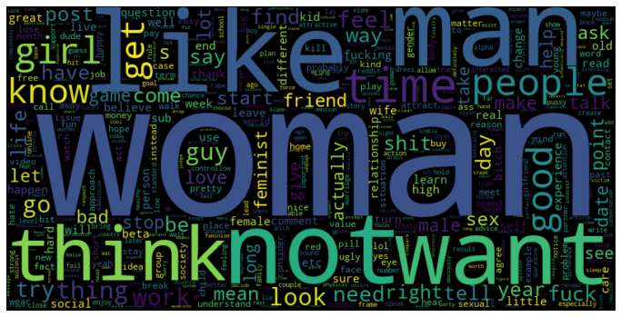

```python
# Visualizing common words for misogynistic comments in a word cloud.
# The larger the words in the cloud, the more the word occures in observations.
token_freq = FD(dict_comments)
wc = WordCloud(width=800, height=400, max_words=500).generate_from_frequencies(token_freq)
plt.figure(figsize=(12,10))
plt.imshow(wc, interpolation='bilinear')
plt.axis('off')
plt.show()
```

In this word cloud we can observe that the majority of words has a focus on women and verbs, which does make sense considering the data revolves around misogyny.

Since misogyny is specifically hate towards women we think these tokens look good for further use in machine learning as we want the algorithms to learn to distinguish when a text is specifically making unfair assumptions about women in a derogatory way.